# Demographic effects on Crime

Doug Walton, DureSameen Awan, Erika Garces

May 4, 2016

# Demographic Effects on Crime

## Motivation

Crime is any act that causes harm to individual(s), communities, society or state. Crime is a topic that terrorizes yet fascinates many people including all our team members. Crime stories are showcased all over media and gain much attention. Popular crime topics include murder (homicide) or rape. Our team members background includes interests in psychology, dynamics of social change and criminology. All the team members are fascinated with exploring effects of demographics on crime.

Crime changes from state to state, from form to frequency. Why? What are the demographic factors that make people commit a crime? Will there be any interesting relationships between crimes and demographics?

## Overview

In this project, we explore the above questions using publically available data from various U.S. sources and associated R packages. In particular, we will explore whether homicide or rape seems associated with any identifiable demographic factors. This will give insight into the research possibilities for using these datasets with this kind of social science question. The question we will attempt to answer within this project is: Are demographics correlated with the prevalence of either homicide or rape? If yes, then which ones.

# Goal

To identify key demographic factors that predict the prevalence of homicide or rape. Identify if these influences are better understood at national or state level. We will let the data guide us, our scope will be to cover all the states in USA.

Demographic factors we will explore and limit our analysis to are:

Effects of 1. Household type 2. Age 3. Gender 4. Race 5. Education 6. Income and 7. Population on homicide and rape across U.S. States.

### SCOPE

We started this project with the goal of analyzing demographic effects on USA, Canada and European countries. When collecting the data we ran through so many problems and inconsistencies and due to time shortage that we decided to scale back our scope to USA and its states only.

1. Household type (only list and use the percent of single family huseholds)
2. Age (median age)
3. Gender (male vs female ratio in population - if majority of male then more crime?)
4. Race (a particular race is more prominent in crime areas)
5. Education (only look at groups that are less then university degree; or and % that didnt pass highschool - prediction here is the more highschool dropouts the more crime)
6. Income (median income and its impacts on crime over the years)
7. Population (prediction here is lower population means higher crime rate)

# Approach

Our research followed two different approaches. The first is a historical approach to see how thing changed over time across nations under study. The second is a comparison between state-to-state and county-to-county to see effects of demographics on crime.

## Approach #1

We will ook at national data over time. In particular we will be exploring how demographic effects on crime within USA over time.

## Approach #2

We will look at 2012 data for all U.S. states for all demographic data to fnd trends. Then doing a deeper dive of previous years for particular states.

we will be using the following libraries in our analysis:

```r
suppressMessages (library(dplyr))
library(tidyr)
library(ggplot2)
library(readr)
library(broom)
library(knitr)
```

## Data Collection Note:

Starting with tables derived from the 2012 Statistical Abstract of the United States http://www.census.gov/library/publications/2011/compendia/statab/131ed.html

1. us_national.csv is population by year from 1900 to 2015. initially derived from Section 1, Tables 1 & 2. Lagging zeros filled in on earlier years to make everything in consistent units (removed ’000s reduction). Added years 2010 to 2015 from PEPANNRES annual estimates of population (found through American Fact Finder.)

We then take selected chosen areas from different census tables to add to this national master.

A based table is constructed from the UC census table 12s0059.xls from the U.S. Statistical Abstract 2012, which covers 1960 to 2010, and then selected householder characteristics for 2011 to 2014 are added from the ACS filess and B11001, B11001A, B11001I to create 12s0059-households.csv. (Tables can be found using American Fact Finder)

3. Income. This table gives income for varous ethnic groups and males/females from 1947 to 2009 in 2009 dollars. Since, the ways that income has has been reported seems to have shifted in 2002 such that some categories like “White” have subgroups instead, some adjustments were made. The subgroups are similar, so I just averaged them back into the top line. Those distinctions aren’t going to make much of a difference for a modeling the fit (or could be more fully explored later).
4. Educational attainment. The table is constructed from 12s0230.xls as the base. It gives 1960 to 2010 for sex and ethnicity, but only high school+ and college+ were available. Later years would have to be added from ACS tables in the C15002 series, but the categorization of educational attainment is diferrent, making the matching of the numbers difficult.
5. Murder and Rape. Compiled from the table generator of the FBI Uniform Crime Reporting system (UCR) into files ucr-us-murder1960-2012.csv and ucr-us-rape1960-2012.csv

### DATA SCRAPING, CLEANUP AND LESSONS LEARNED

The the majority of data on US demographics comes from the US Census Bureau, the FBI’s Uniform Crime Reporting (UCR) database, the U.S. Bureau of Justice, and the U.S. Bureau of Labor. Most other sites that show U.S. demographics are pulling from those.

While those sources are extensive, getting the data you want for analysis is challenging because the available data is in a wide variety of tables and formats. There is so much data, much of it with particular nomenclature that has to be learned, that it takes time just to find what you are looking for. Then, these tables have different spans of years, different labeling, overlapping data series, differing levels of detail, complicated formatting, and changing assumptions over time.

To deal with this, we selected a set of the relevant tables and stitched them together into tables with the data that we needed. Some tables were used directly. But creating a time series of many factors together involved creating a master table by year. This involved the following:

Excel was used to strip out complicated formatting of footnotes, headings, hidden columns, and special characters inside columns and row labels. In some cases, certain small, simpler tables were pasted together using excel The csv files were then read into R and manipulated to transpose the columns to a common format and labeling, strip out misaligned data, and convert the tables to consistent data formats. In R, a few of the tables required some addition of percentage columns or conversion of the column to or from 1000s of population. In some cases, the data was acquired using R packages ‘acs’ and ‘UScensus2010’ and written back out to CSVs to be used elsewhere A key learning about the data is that you can have a huge amount of data, even for over a hundred years, and it is still not always perfectly connected to reality. The census data is acquired from interviews that change over the years, and they make many of their own assumptions and predictions to provide the data. So using the data comes with its own set of assumptions that can be easily overlooked when imported into what looks like a clean table in R.

The next time around, the work would in part be easier by just knowing the structure of the census data and also being aware of how to use census-related R packages. We did not discover how to work with these until later. Also there were chronic problems with transposing tables to get the years in rows. Functions could be written to streamline this and clean up the code.

### Approach 1: National Level

We started our approach with uploading the data files and performing some data cleansing and joins.

```r
# Starting with a base table US national population data by year from 1900
uspop <- read.csv("us_national.csv")
uspop$year <- as.character(uspop$year)

# Add household data and select out key types that might we worth looking at
# years 1960 to 2014
UShousehold <- read.csv("Sources/12s0059-households.csv")
UShousehold$Type.of.unit <- as.character(UShousehold$Type.of.unit)
UShousehold$Type.of.unit[3:9] <- c("Household_white","Household_black","Household_hispanic","fam_household","couple_household","male_household","fem_household")
UShousehold_s <- UShousehold %>% slice(1:9) %>% select(-X1960) # eliminate gap
cols <- UShousehold_s$Type.of.unit
UShousehold_s <- as.data.frame(t(UShousehold_s[,-1]))
colnames(UShousehold_s) <- cols
UShousehold_s <- add_rownames(UShousehold_s, "year")
# UShousehold$year <- as.factor(UShousehold$year)
usnat <- uspop %>% left_join(UShousehold_s, by = 'year')

# Add income data for age, sex, and major ethnic groups in 2009 dollars
# years 1947 to 2009
USincome <- read.csv("Sources/12s0701-median-income-2009-dollars.csv")
USincome$X <- as.character(USincome$X)
cols <- USincome$X
USincome_s <- as.data.frame(t(USincome[,-1]))
colnames(USincome_s) <- cols
USincome_s <- add_rownames(USincome_s, "year")
usnat <- usnat %>% left_join(USincome_s, by = 'year')

# Educational attainment 1960 to 2010 for age, sex, major ethnicity
USedu <- read.csv("Sources/12s0230-education.csv")
USedu$year <- as.character(USedu$year)
usnat <- usnat %>% left_join(USedu, by = 'year')

# Ppulation subgroups by ethnicity and sex 2000 to 2010
USbasic2010 <- read.csv("Sources/US-EST00INT-ALLDATA.csv")
USbasic2010 <- USbasic2010 %>% filter(AGE != '999' & MONTH != '4')
USbasic2010 <- USbasic2010[,-1]

USbasic2010sum <- USbasic2010 %>% group_by(YEAR) %>% summarise(tot_male = sum(TOT_MALE), tot_female = sum(TOT_FEMALE), white_male_pop = sum(WA_MALE),white_female_pop = sum(WA_FEMALE),black_male_pop = sum(BA_MALE),black_female_pop = sum(BA_FEMALE),hisp_male_pop = sum(H_MALE),hisp_female_pop = sum(H_FEMALE))


USbasic2010sum <- rename(USbasic2010sum, year = YEAR)
USbasic2010sum$year <- paste0("X",USbasic2010sum$year)
usnat <- usnat %>% left_join(USbasic2010sum, by = 'year')

# Adding homicide and rape data 1960 to 2012
UScrime <- read.csv("Sources/12s0306-tot_in_thousands_ofcrimetype1980-2009.csv")
UScrime<- UScrime %>% mutate (year1= year)
UScrime$year <- paste0("X",UScrime$year)
UScrime[2:6] <- UScrime[2:6] * 1000
usnat2 <- usnat %>% left_join(UScrime, by = 'year')
```

As can be seen in the tables and commentary above, while there is a considerable amount of data available, compiling a longitudinal view is challenging because the data was collected in differing ways over decades, with differing assumptions and labels. Some of the data is already based on approximations by US census bureau, and to join the tables into a continous data series for decades involves further assumptions about how closely one category is like another. At a macro-level, this may not matter much for initially finding productive opportunities for research, but it is something to be kept in mind for later verification.

### National Rate of Homicide and Rape

[figure not shown]

```r
# Making a sub table of just specific data of interest to make the data easier to manipulate and show
# households was in 1000s, crimes in total numbers
rap_hom <- usnat2 %>% filter(year1 >= '1960' & year1 <= '2012')%>% mutate(murderpct = murder/residents*10000, rapepct = forcible_rape/residents*10000)

# Graph of murders and rape trend over the last few decade
rap_hom  %>% ggplot(aes(year1)) + geom_point(aes(y = murderpct, col = "Murder")) + geom_point(aes(y=rapepct, col="Rape")) + labs(title="U.S. Forcible Rape and Murder Trends", y = "Rate per 100k", col="Values", x="year")
```

# Now lets take a closer look at the rape trend only but fitting a line to rape data using loess

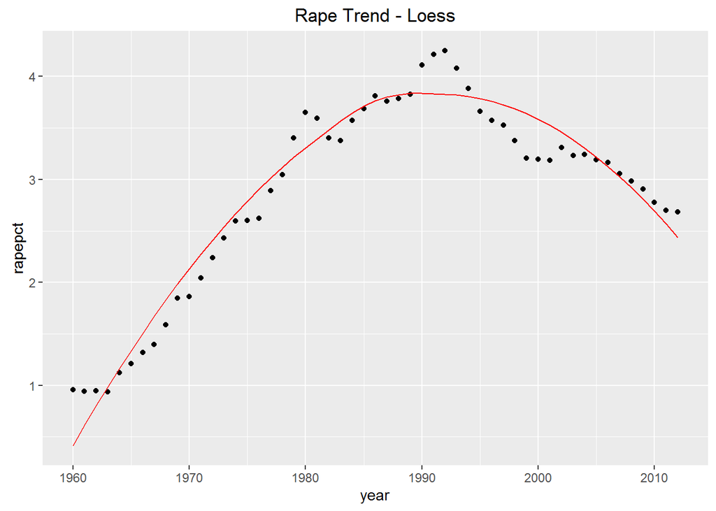

```r
# rape data
dat <- rap_hom %>% select(year, rapepct,murderpct)
dat$year1 <- seq(1960,2012)

# fitting line to rape data using loess to see about the trend
mod <- loess(rapepct~year1, degree=2, span = 1, data=dat)
loess_fit <- augment(mod)

dat %>% ggplot(aes(year1)) + geom_point(aes(y=rapepct)) + geom_line(aes(x=year1, y=.fitted), data=loess_fit, color="red") + labs(title="Rape Trend - Loess", x ="year")
```

# A significant pattern can be seen here in rape rates throughout the years, it started with rape rates increasing up until early 1990s and then all of a sudden the rates started to drop significantly and have been on a downward trend ever since.

Now lets see if we see any trends in the murder rates

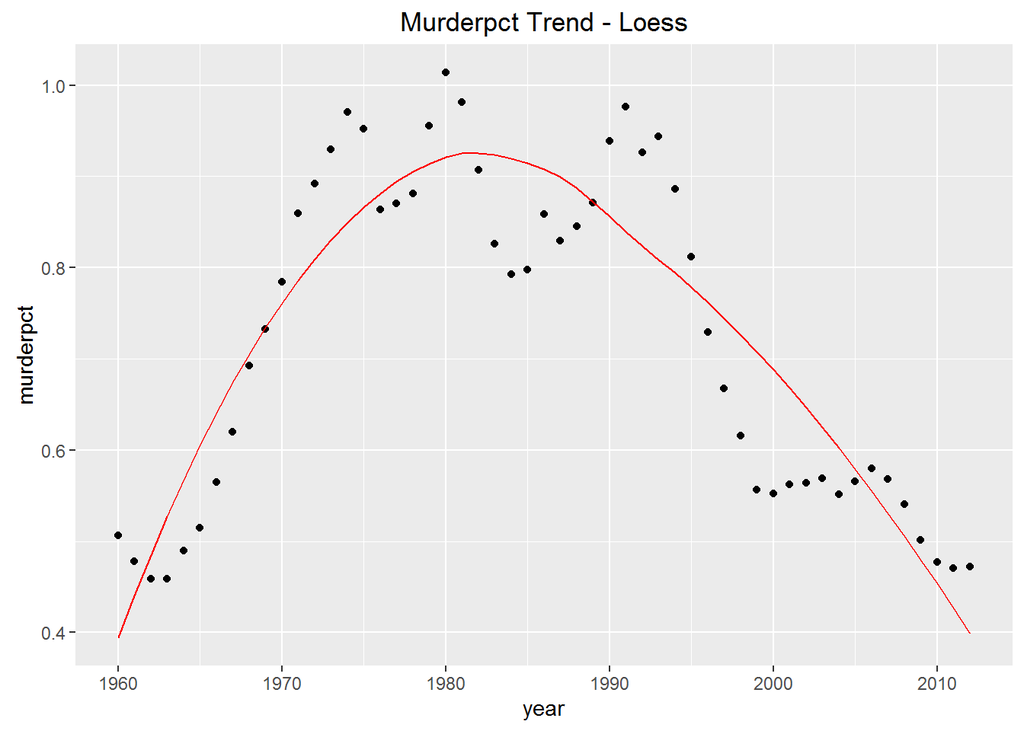

```r
# fitting line to murderpct data using loess to see about the trend
mod <- loess(murderpct~year1, degree=2, span = 1, data=dat)
loess_fit <- augment(mod)

dat %>% ggplot(aes(year1)) + geom_point(aes(y=murderpct)) + geom_line(aes(x=year1, y=.fitted), data=loess_fit, color="red") + labs(title="Murderpct Trend - Loess", x ="year")
```

A similar pattern is spotted in the murder data, this time the peak was alot earlier in the 1980s and murder rates have been decreasing ever since. The declining slope is steeper in murder rates then rape rates.

#### 1. Household type

We assume that single parent families would have higher crime rate overall than nuclear family systems, lets see if the data supports that theory.The graphs below only take into account single male and single female households and compare them to rape and murder rates.

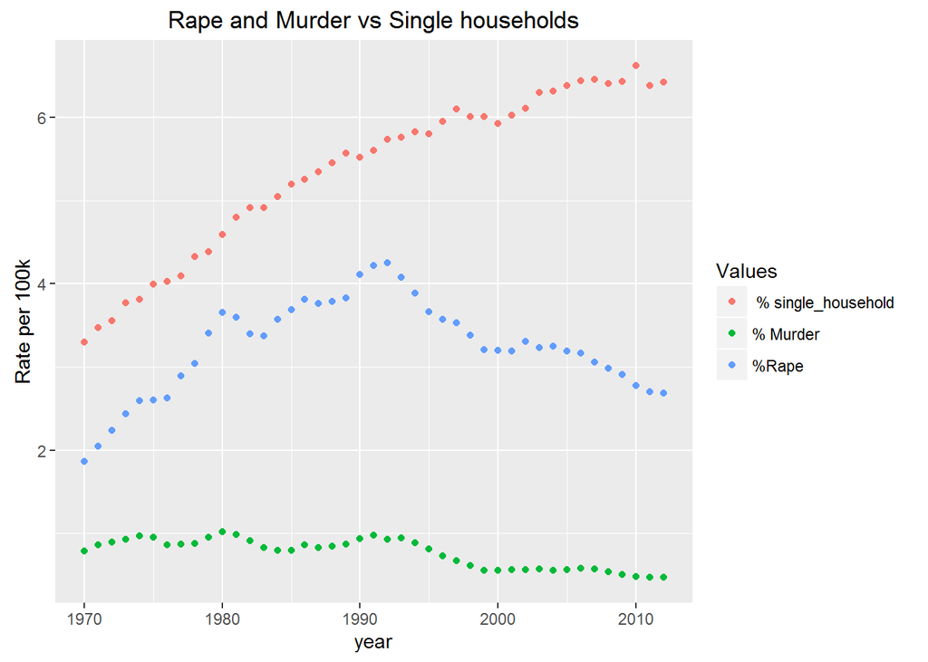

```r
ushousehold <- rap_hom %>% mutate (single_householdpct =((male_household + fem_household)/residents)*100000)%>% mutate(housepct = (couple_household/residents)*100000)


ushousehold%>%filter(year1>=1970)%>%ggplot(aes(year1)) + geom_point( aes(y=single_householdpct, color = " % single_household"))+ geom_point(aes(y=rapepct, color = "%Rape")) +geom_point( aes(y=murderpct, color = "% Murder"))  +labs(title="Rape and Murder vs Single households", y = "Rate per 100k", col="Values", x="year")
```

Up until the 1990s single family households had the same upward trend like rape; that is as single family households increased, rape rate increased. But after 1990s rape rates dropped significantly and have been on a downward trend even though single families rate is increasing nationally.

#### 2. Age (median age)

We will now examine the impacts of age on rape and murder. In particular we will look at the national median age across the years and and any corelations it may have with rape or murder.

We will first add the data in manually in arrays as our data source is a pdf file (Data source: [US census Bureau](https://www.census.gov/prod/cen2010/briefs/c2010br-03.pdf)).

```r
year1 <- seq(1960,2010, 10)
under18 <- c(24.0,25.7,25.6,28.1,34.3,35.9)
under44 <- c(36.5,39.9,43.2,40.9,35.3,34.8)
over65 <- c(26.4,22.0,18.6,19.6,20.6,20.3)
median <- c(29.5,28.1,30.0, 32.9,35.3,37.2)
hist_pop <- data.frame(year1,under18,under44,over65,median)
kable(hist_pop)
```

| year1 | under18 | under44 | over65 | median |
| --- | --- | --- | --- | --- |
| 1960 | 24.0 | 36.5 | 26.4 | 29.5 |
| 1970 | 25.7 | 39.9 | 22.0 | 28.1 |
| 1980 | 25.6 | 43.2 | 18.6 | 30.0 |
| 1990 | 28.1 | 40.9 | 19.6 | 32.9 |
| 2000 | 34.3 | 35.3 | 20.6 | 35.3 |
| 2010 | 35.9 | 34.8 | 20.3 | 37.2 |

We will now plot the median age data against the rape curve

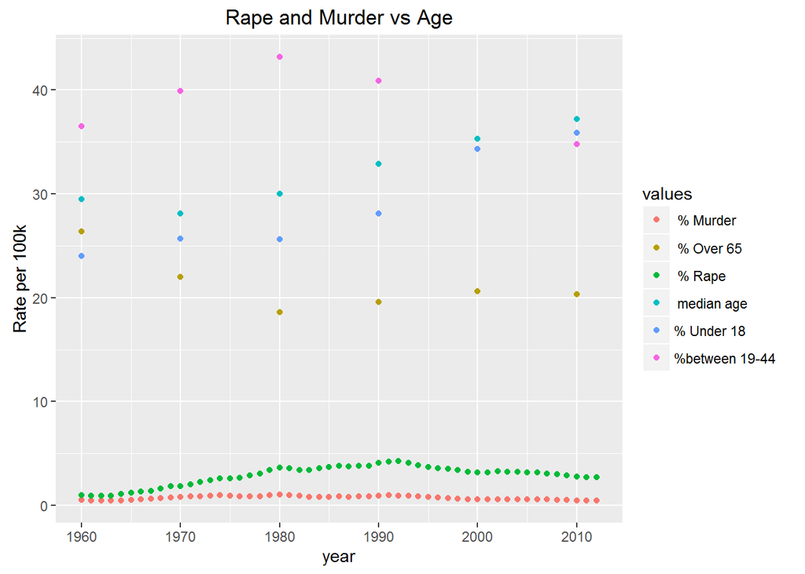

```r
age<-ushousehold%>% left_join(hist_pop)
age%>%ggplot(aes(year1)) + geom_point(aes(y=under44, color = "%between 19-44"))  + geom_point(aes(y=under18, color = "% Under 18"))  +  geom_point(aes(y=over65, color = " % Over 65"))  +  geom_point(aes(y=median, color = " median age"))  +
geom_point(aes(y=murderpct, color = " % Murder"))+ geom_point(aes(y = rapepct,color=" % Rape ")) +labs(title="Rape and Murder vs Age", y = "Rate per 100k", x="year", col="values")
```

#### 3. Gender

We will now shift our focus to impacts of gender on national rape and murder rate. The assumption we made was that maybe rape and murder is related to more male populations. Lets see if our assumption holds true

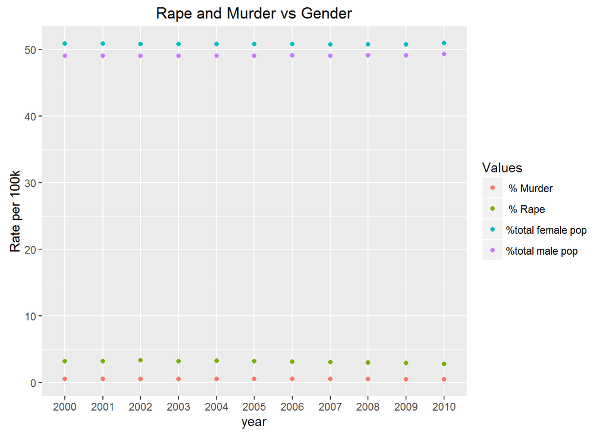

```r
gender<-ushousehold%>%select(tot_male,tot_female,murderpct,rapepct,residents,year1)%>% mutate(tot_male = tot_male/residents*100)%>% mutate(tot_female = tot_female/residents*100)%>%filter(year1>=2000 & year1<=2010)
gender$year1 <- as.character(gender$year1)

gender%>%ggplot(aes(year1)) + geom_point(aes(y=tot_male, color = "%total male pop"))  + geom_point(aes(y=tot_female, color = "%total female pop"))  +
geom_point(aes(y=murderpct, color = " % Murder"))+ geom_point(aes(y = rapepct,color=" % Rape ")) +labs(title="Rape and Murder vs Gender", y = "Rate per 100k", x="year", col="Values")
```

Unfortunately since the ratio of men and women in USA is very close (49%-51%) we could not really relate gender impacts to crime rate.

#### 4. Race

Now will look to see if a particular race is more prominent in crime areas. That is, does immigration (non-white population) impact crime rate? Our assumption is, the more immigration (non-white) population that enters the USA the lesser the crime rates. Lets see if this assumption holds:

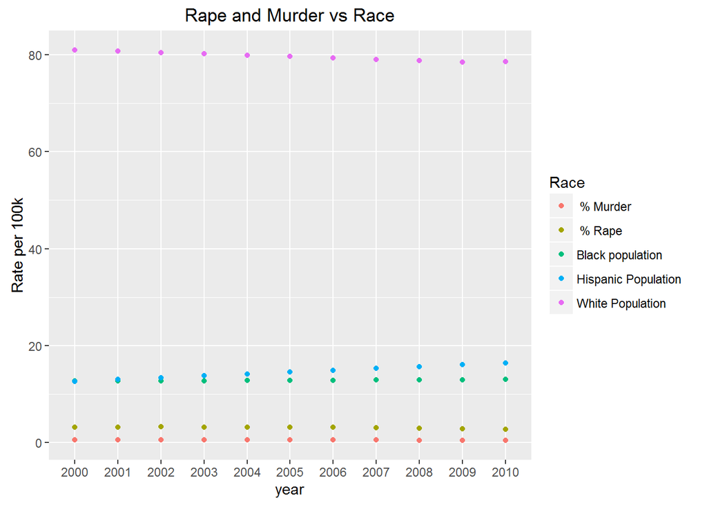

```r
race<-ushousehold%>%mutate(white_pop= ((white_male_pop+ white_female_pop)/residents*100)) %>%mutate(black_pop= (black_male_pop+ black_female_pop)/residents*100) %>%mutate(hisp_pop= (hisp_male_pop+ hisp_female_pop)/residents*100)


race<-race%>%filter(year1>=2000 & year1<=2010)
race$year1 <- as.character(race$year1)

race%>%ggplot(aes(year1)) + geom_point(aes(y=white_pop, col="White Population")) + geom_point(aes(y=black_pop, col="Black population")) + geom_point(aes(y=hisp_pop, col="Hispanic Population")) + geom_point(aes(y=murderpct, color = " % Murder"))+ geom_point(aes(y = rapepct,color=" % Rape "))+ labs(title="Rape and Murder vs Race", y="Rate per 100k", col="Race", x= "year")
```

#### 5. Education

Our assumption is that education definitely plays a big part in crime rates; the more educated the population the less likely they are to commit a crime or get in trouble with the law. In our analysis we are looking at national rate of population that did not get an education higher than high school and comparing that to rape and murder rates.

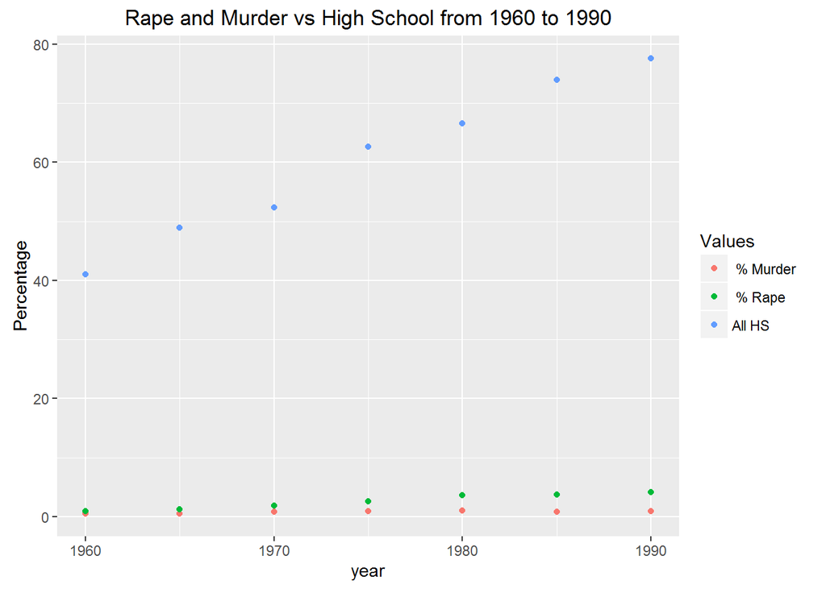

```r
Edu <- rap_hom%>%mutate(hs=(hs.all.male+ hs.all.female)/2)%>%mutate(coll=(col.all.male+ col.all.female)/2)%>%filter(coll!=is.nan(coll))


Edu%>% filter(year1>=1960 & year1<=1990)%>% ggplot(aes(year1)) + geom_point(aes(y=hs,  col='All HS')) +geom_point(aes(y=murderpct, color = " % Murder"))+ geom_point(aes(y = rapepct,color=" % Rape "))+ labs(title="Rape and Murder vs High School from 1960 to 1990", y="Percentage", col="Values", x= "year")
```

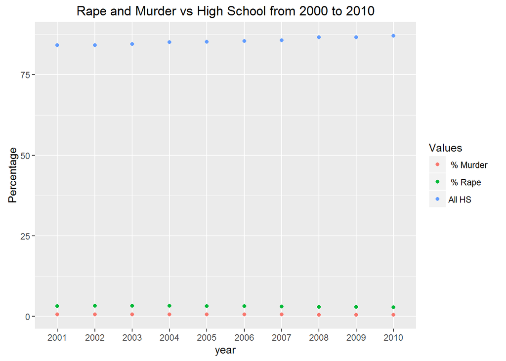

```r
Edu<-Edu%>% filter(year1>=2000 & year1<= 2010)
Edu$year1 <- as.character(Edu$year1)

Edu%>% ggplot(aes(year1)) + geom_point(aes(y=hs,  col='All HS')) +geom_point(aes(y=murderpct, color = " % Murder"))+ geom_point(aes(y = rapepct,color=" % Rape "))+ labs(title="Rape and Murder vs High School from 2000 to 2010", y="Percentage", col="Values", x= "year")
```

In the latest decade (2001-2010) we dont really see much of a trend. Not sure what other contributing factors are the cause, it could be the internet and the introduction of social media where people can voice their opinions that changed this trend.

#### 6. Income

Our assumption is that low median icome means higher crime rates.

We started our analysis with just looking at overall male vs female income.

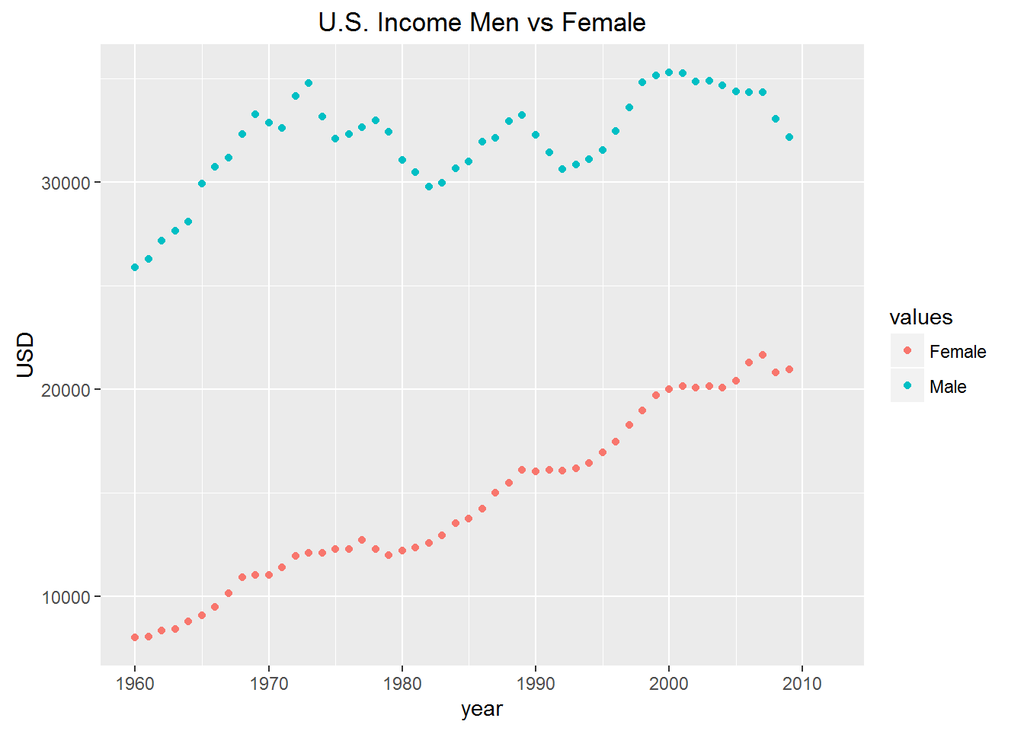

```r
ushousehold%>% ggplot(aes(year1)) + geom_point(aes(y=inc_median_all_male, col="Male")) + geom_point(aes(y=inc_median_all_female, col="Female"))+labs(title="U.S. Income Men vs Female", y = "USD", x= "year", col="values")
```

Let us now compare medan income to crime rate, do they have a similar trend like income disparity did on crime. Lets see:

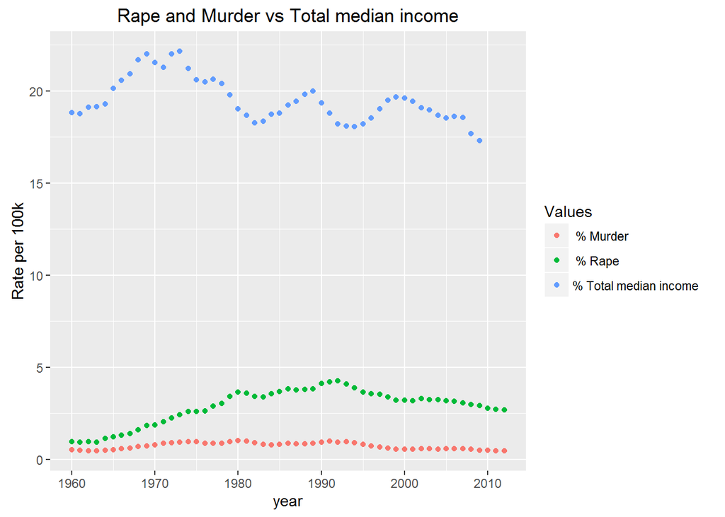

```r
income<-rap_hom%>%mutate(total_income=(inc_median_all_male+inc_median_all_female)/2)%>%mutate(total_incomepct=((inc_median_all_male+inc_median_all_female)/residents*100000))

income%>% ggplot(aes(year1)) + geom_point(aes(y=total_incomepct,  col='% Total median income')) +geom_point(aes(y=murderpct, color = " % Murder"))+ geom_point(aes(y = rapepct,color=" % Rape "))+ labs(title="Rape and Murder vs Total median income", y="Rate per 100k", col="Values", x= "year")
```

## 7. Population

impacts of population on murder and rape rates

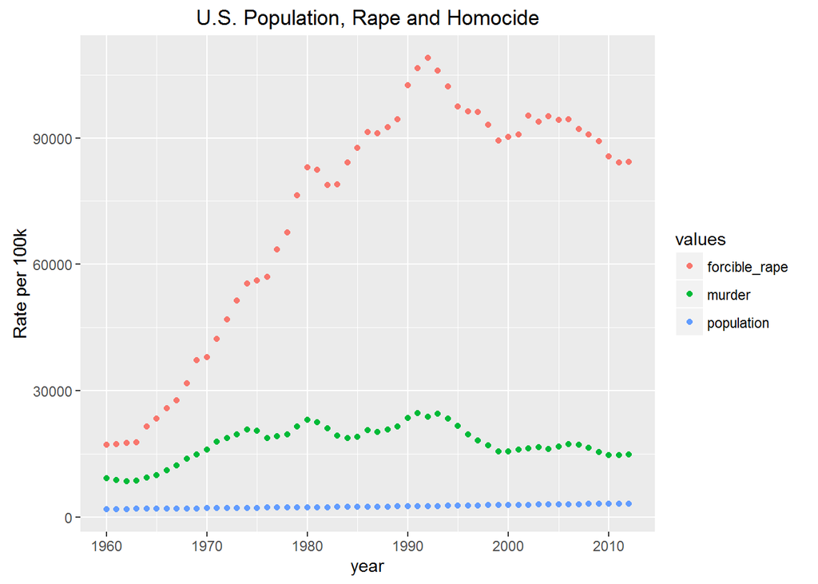

```r
ushousehold %>% ggplot(aes(year1))+ geom_point(aes(y=forcible_rape, col="forcible_rape")) +geom_point(aes(y=murder, col="murder")) + geom_point(aes(y=residents/100000, col="population")) + labs(title="U.S. Population, Rape and Homocide", y = "Rate per 100k", x= "year", col="values")
```

Is there a model of some of these key factors that would fit this? Here we take selected factors pertaining to traditional households, income, and educational attainment and try to fit a model. (glm or lm? not sure it makes a difference but maybe take a closer look)

```r
usnat_sub1 <- usnat2 %>% filter(year <= 'X2010' & year >= 'X2000') %>% mutate(murderpct = murder/(residents/1000), rapepct = forcible_rape/(residents/1000), housepct = (couple_household/residents)*1000)

# here a logisic regression is fit for murder.
fit <- usnat_sub1 %>% glm(murderpct ~ couple_household + inc_median_all_male + inc_median_all_female + hs.all.male + hs.all.female + col.all.male + col.all.female, data = .)
summary(fit)
```

```
##
## Call:
## glm(formula = murderpct ~ couple_household + inc_median_all_male +
##     inc_median_all_female + hs.all.male + hs.all.female + col.all.male +
##     col.all.female, data = .)
##
## Deviance Residuals:
##          2           3           4           5           6           7
## -9.005e-04   5.525e-04  -3.805e-04   1.812e-04   5.443e-04   9.813e-04
##          8           9          10
## -6.326e-04  -5.178e-05  -2.939e-04
##
## Coefficients:
##                         Estimate Std. Error t value Pr(>|t|)
## (Intercept)           -3.287e-01  4.677e-01  -0.703    0.610
## couple_household       9.378e-07  4.963e-06   0.189    0.881
## inc_median_all_male    1.275e-06  5.251e-06   0.243    0.848
## inc_median_all_female -7.282e-08  2.971e-06  -0.025    0.984
## hs.all.male           -4.059e-03  8.321e-03  -0.488    0.711
## hs.all.female          9.968e-03  1.565e-02   0.637    0.639
## col.all.male          -4.286e-03  5.557e-03  -0.771    0.582
## col.all.female        -3.611e-03  1.003e-02  -0.360    0.780
##
## (Dispersion parameter for gaussian family taken to be 3.042075e-06)
##
##     Null deviance: 4.2976e-05  on 8  degrees of freedom
## Residual deviance: 3.0421e-06  on 1  degrees of freedom
##   (2 observations deleted due to missingness)
## AIC: -90.561
##
## Number of Fisher Scoring iterations: 2
```

```r
# here a logisic regression is fit for rape
fit <- usnat_sub1 %>% glm(rapepct ~ couple_household + inc_median_all_male + inc_median_all_female + hs.all.male + hs.all.female + col.all.male + col.all.female, data = .)
summary(fit)
```

```
##
## Call:
## glm(formula = rapepct ~ couple_household + inc_median_all_male +
##     inc_median_all_female + hs.all.male + hs.all.female + col.all.male +
##     col.all.female, data = .)
##
## Deviance Residuals:
##          2           3           4           5           6           7
## -0.0063582   0.0039011  -0.0026869   0.0012795   0.0038429   0.0069287
##          8           9          10
## -0.0044665  -0.0003656  -0.0020750
##
## Coefficients:
##                         Estimate Std. Error t value Pr(>|t|)
## (Intercept)            9.278e-01  3.302e+00   0.281    0.826
## couple_household       2.423e-06  3.505e-05   0.069    0.956
## inc_median_all_male    7.812e-06  3.707e-05   0.211    0.868
## inc_median_all_female -5.911e-06  2.098e-05  -0.282    0.825
## hs.all.male           -5.184e-03  5.875e-02  -0.088    0.944
## hs.all.female         -8.824e-03  1.105e-01  -0.080    0.949
## col.all.male           7.873e-03  3.924e-02   0.201    0.874
## col.all.female         2.494e-03  7.079e-02   0.035    0.978
##
## (Dispersion parameter for gaussian family taken to be 0.0001516652)
##
##     Null deviance: 0.00140200  on 8  degrees of freedom
## Residual deviance: 0.00015167  on 1  degrees of freedom
##   (2 observations deleted due to missingness)
## AIC: -55.379
##
## Number of Fisher Scoring iterations: 2
```

# Approach 2

In approach 2, we compare state to state for the year 2012. This was the latest year for which a good set of the needed data was available.

In this section, we focus more on rape specifically, because in the national views there was divergence where rape around the 1990s seemed to significantly increase over murder rate. This suggests there are unique factors that might be interesting.

# State Demographic Data

State data for 2012 compiled from multiple American Community Survey tables (US Census Bureau) and from the FBI Uniform Crime Reporting database.

```r
stdem <- read.csv("states-key-demographics-2012.csv")
```

```r
# Population by state - choropleth view
# inspired by - See more at: http://www.trulia.com/blog/tech/the-choroplethr-package-for-r/
# can be installed from CRAN
# USCensus API key needed install one time. To obtain: http://api.census.gov/data/key_signup.html to get the key
# then api.key.install(key="592bc14cnotarealkey686552b17fda3c89dd389") (example, done one time)
# see http://eglenn.scripts.mit.edu/citystate/wp-content/uploads/2013/06/wpid-working_with_acs_R3.pdf for acs package info.

library(choroplethr)
library(acs)
library(choroplethrMaps)
```

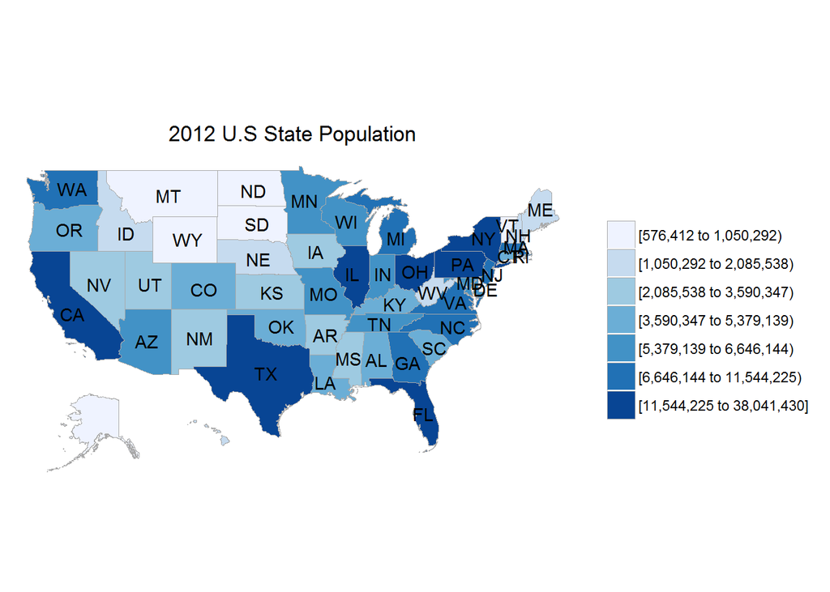

```r
data("state.map")

# state population graphic
# extract and set to expectation of choropleth package
sf <- stdem %>% select(State,tot_pop)
colnames(sf) <- c("region","value")
sf$region <- tolower(sf$region)

state_choropleth(sf, title = '2012 U.S State Population')
```

Alernative view of population by state - graph view

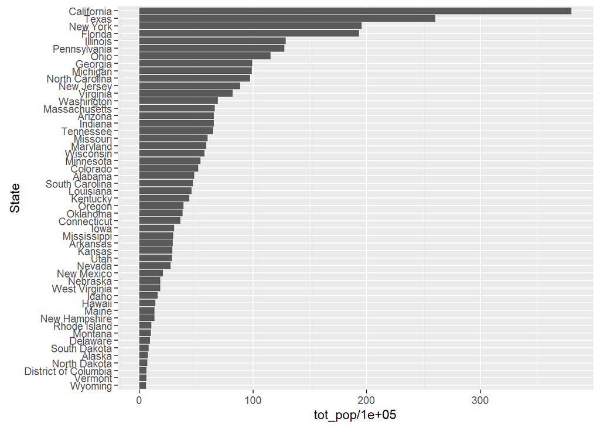

```r
stbypop <- stdem %>% arrange(tot_pop)
stbypop$State <- factor(stbypop$State, levels = stbypop$State)
stbypop %>% ggplot(aes(x= State, y = tot_pop/100000)) + geom_bar(stat = "identity") + coord_flip()
```

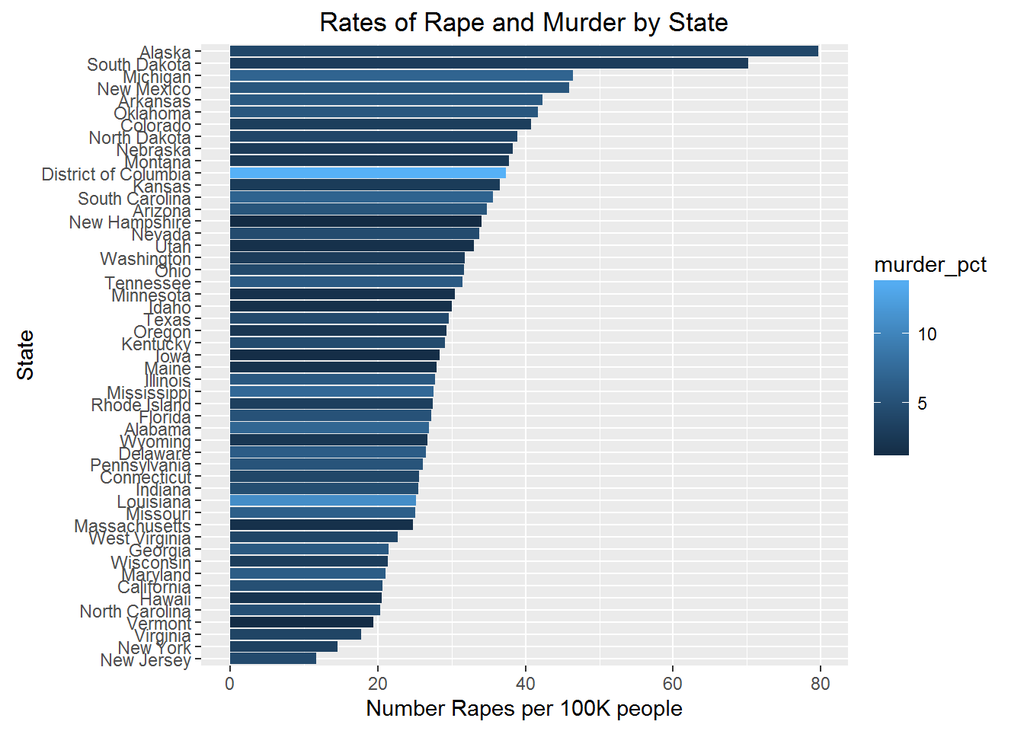

```r
# PUt in the percent for Murder and Rape  by State
stcrime <-stdem
stcrime <- stcrime %>% mutate(rape_pct = num_rapes/tot_pop * 100000, murder_pct = num_murder/tot_pop * 100000)
stcrime <- stcrime %>% arrange(rape_pct)
stcrime$State <- factor(stcrime$State, levels = stcrime$State)

# Make the graph for rape and murder - would be nice if clustered bar
stcrime %>% ggplot(aes(x= State, y = rape_pct, fill = murder_pct)) + geom_bar(position='dodge',stat = "identity") + coord_flip() + labs(title = "Rates of Rape and Murder by State", y = "Number Rapes per 100K people")
```

The bars of the graph show the rape percent, and the color shows the murder percent. As the blue colors are fairly widely distributed, there doesn’t seem to be a high correspondence of murder to rape.

We now look at the four best and worst states and see if there is any relations there.

```r
# worst states
ws <- stcrime %>% arrange(desc(rape_pct)) %>% select(State, rape_pct)

kable(head(ws, n=4), digits = 2, col.names = c("State","Rapes per 100K"), caption = "Highest Number of Rapes")
```

Highest Number of Rapes

| State | Rapes per 100K |
| --- | --- |
| Alaska | 79.70 |
| South Dakota | 70.20 |
| Michigan | 46.43 |
| New Mexico | 45.89 |

```r
# best states
bs <- stcrime %>% select(State, rape_pct)
kable(head(bs, n=4), digits = 2, col.names = c("State","Rapes per 100K"), caption = "Lowest Number of Rapes")
```

Lowest Number of Rapes

[output not shown]

In this next part, we explore a number of factors that could contribute to a high incidence of rape. A similar format is used to compare the factor against the rate of murder. We had to go through a few different visualizations before we could find any relation between the demographic and rape rate; this goes to show that using the right visualizations for the data is a key element in analyzing any data.

visualization version 1: Median age - colored state version

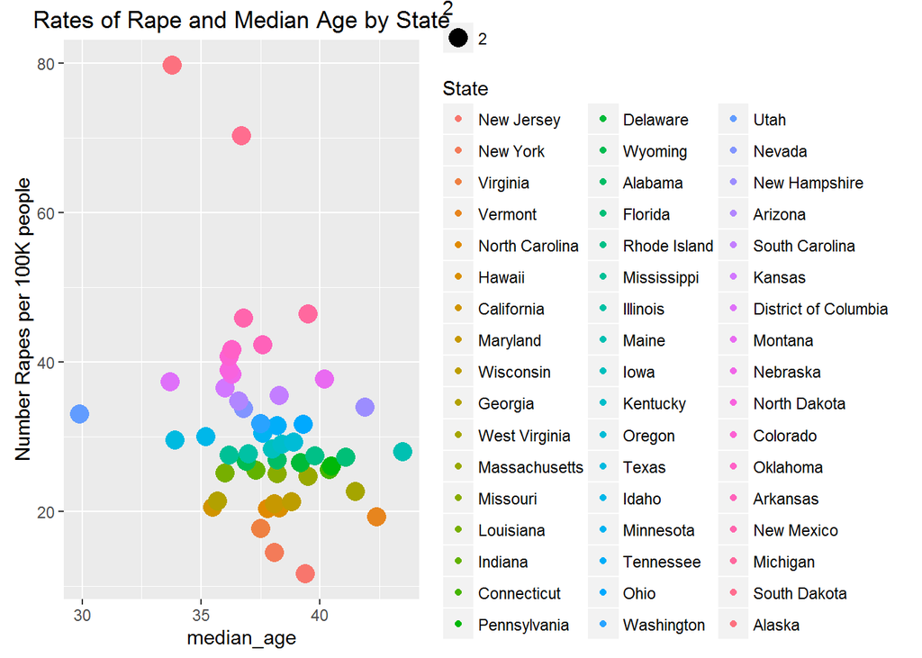

```r
# Median age - colored state version
stcrime %>% ggplot(aes(x= median_age, y = rape_pct, fill = State, color=State, cex = 2)) + geom_point() + labs(title = "Rates of Rape and Median Age by State", y = "Number Rapes per 100K people")
```

visualization version 2: Median age - lm smoothed line

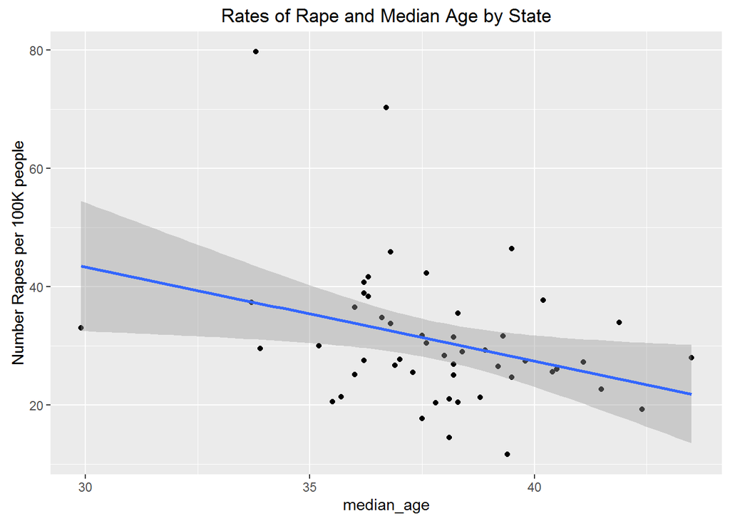

```r
# Median age - lm smoothed line
stcrime %>% ggplot(aes(x= median_age, y = rape_pct)) + geom_point() + labs(title = "Rates of Rape and Median Age by State", y = "Number Rapes per 100K people") + geom_smooth(method = lm)
```

visualization version 3: Median age - loess smoothed line

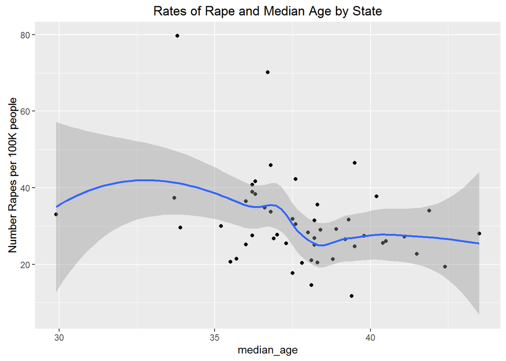

```r
# Median age - loess smoothed line
stcrime %>% ggplot(aes(x= median_age, y = rape_pct)) + geom_point() + labs(title = "Rates of Rape and Median Age by State", y = "Number Rapes per 100K people") + geom_smooth()
```